# 2022-1_TermProject

sanghyeok

2022-06-11

# 1. 개요

## 1.1. 이슈

최근, 전국장애인차별철폐연대의 지하철 운행 방해 시위로 인해 장애인 이동권 보장에 이슈를 받음

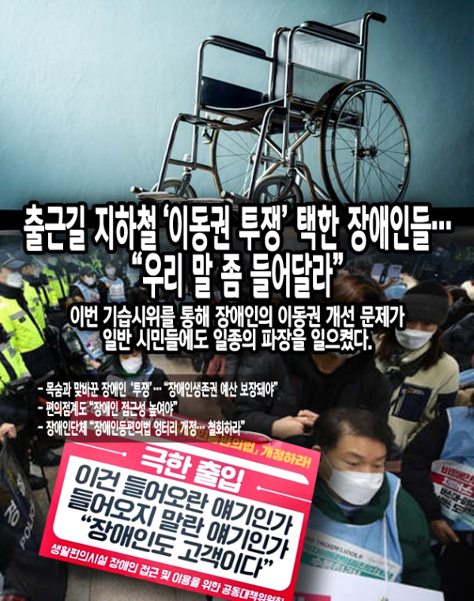

picture1

서울연구원 자료에 의하면, 서울시 교통약자는 약 26%에 달하며 고령 인구의 증가와 함께 교통 약자의 비율도 증가하는 추세임

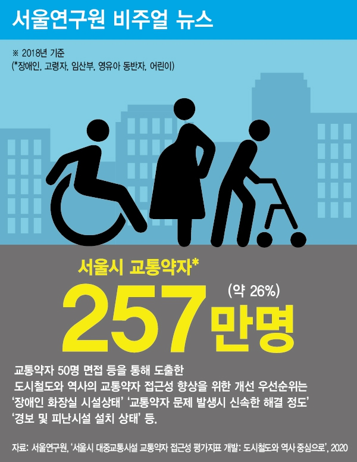

## 1.2. 연구 목적

카드데이터와 열차운행실적 데이터를 활용하여 승객 유형별 승강장 내 이동 시간을 파악 역별 이동 형평성에 대한 평가지표가 될 수 있음

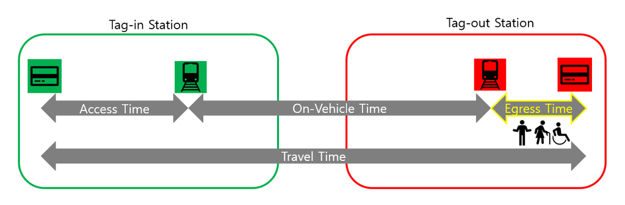

## 1.3. 분석 대상 호선(우이신설선) 개요

[figure not shown]

LineWS

- 13개역, 2량 1편성의 경전철
- 주택가의 승객들을 다른 지하철로 연결해주는 기능
- 민자철도 환승 게이트 데이터를 이용하여 환승 이용객의 경로 추정 가능
- OD별 단일 경로로 이동하였을 가능성이 높아 이용 열차 추정이 용이
- 경로 승객 비중이 큼

# 2. 데이터 개요 및 전처리

### 2.1. 열차운행실적데이터 수집율 파악

- “서울시 지하철 위치정보 Open API 수집시스템”으로 수집한 데이터를 활용
- 보유한 2020.07.01 ~ 2020.10.31 데이터 중 날짜에 따라 수집율이 크게 차이남
  - Available Train : 모든 역에 대한 도착 혹은 출발 정보가 들어있는 열차
  - 10월 한달을 분석 대상 기간으로 선정

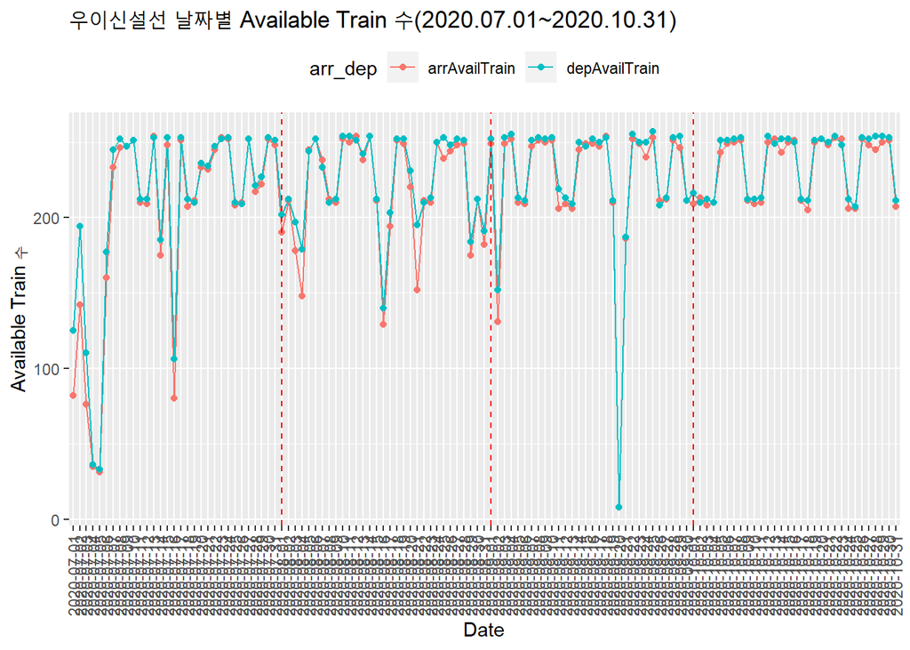

## 2.2. 카드 데이터 전처리

### 2.2.1. 교통카드 데이터(TCD)

```
## [1] "metro_tcd"
```

```
##    V1                                           V2    V3 V4  V5             V6
## 1:  1 yBkv4+ICcu++ttKd/ddQxa5eO6vtWT8VE8t5psyKpWM= 11100  1 107 20201001091228
## 2:  2 yBkv4+ICcu++ttKd/ddQxa5eO6vtWT8VE8t5psyKpWM= 11100  1 107 20201001163245
## 3:  1 yBl0SsDzDpW12UJDrkaW8zSh9xEe9ftgtHacPOKr2/I= 11100  1 105 20201001132926
## 4:  1 yBl2P/U1zT37OOo1pW0CLcbW8bV5NtA4YoPAl4XqN24= 11100  2   2 20201001160656
## 5:  1 yBlAI6Sz0akf88/4aciK+NmDWt32Rcg08GYFRbfRjtY= 11100  1 103 20201001065424
## 6:  1 yBlPVFF4+AlDMnzNxGLnda2gVL5nwAqvG7IrIg/Yn/s= 11100  2 101 20201001124941
##    V7   V8             V9  V10 V11 V12 V13   V14  V15
## 1: NA 1954 20201001092118 1957   1   0 401  3900  530
## 2: NA 1957 20201001174524  331   2   0 401 35100 4359
## 3: NA 1450 20201001134015  432   1   0 401  4700  649
## 4: NA  229 20201001163147 1450   1   0 401  7300 1491
## 5: NA 1901 20201001071827  414   1   0 406  4500 1443
## 6: NA 1707 20201001133735 1805   1   0 401 24500 2874
```

| 1 | 2 | 3 | 4 | 5 | 6 | 7 | 8 | 9 | 10 | 11 | 12 | 13 | 14 | 15 |
| --- | --- | --- | --- | --- | --- | --- | --- | --- | --- | --- | --- | --- | --- | --- |
| 일련번호 | 가상카드번호 | 정산지역코드 | 카드구분코드 | 노선 ID | 승차일시 | 발권시간 | 승차정류장 ID | 하차일시 | 하차정류장 ID | 트랜잭션 ID | 환승횟수 | 사용자구분코드 | 이용거리 | 탑승시간 |

### 2.2.2. 수도권 민자철도 환승게이트 정보 (TGI)

```
## [1] "metro_tgi"
```

```
##          V1 V2                                           V3             V4   V5
## 1: 20201001  2 7ksfVqwg4yB74xyBjxJFk92xlY+PRvXEpbGAlS+DrOc= 20201001114340 4117
## 2: 20201001  2 tmdJ8IlFX12dMg2DGH9jh2txSsTO+N6zAczjRj+yMr8= 20201001122755 4117
## 3: 20201001  2 binUFvYD1qXP7GiTUAjUDsL3TnNhApD8SZzHhus5XMY= 20201001123221 4115
## 4: 20201001  2 O7lmDsvSu+ZMgHl/ZkYovXWulg89WSY/ZohKrgDREr4= 20201001130444 4102
## 5: 20201001  2 MNpvGpall0J6bw9zoyUFyjBG2VPEU+rN9EaZFLHqyhM= 20201001131350 4115
## 6: 20201001  2 DylKE3dV7IjtVBHXQksQ1Y1UsNVFFU2WrBMIKuWAwmk= 20201001130829 4115
##                V6   V7
## 1: 20201001111129 1706
## 2: 20201001114317 1808
## 3: 20201001122505 2525
## 4: 20201001124355 4927
## 5: 20201001123724 2521
## 6: 20201001124643 2519
```

| 1 | 2 | 3 | 4 | 5 | 6 | 7 |
| --- | --- | --- | --- | --- | --- | --- |
| 년월일 | 카드 구분 코드 | 가상 카드번호 | 사용 일시 | 외부 역 번호 | 이전 승하차 일시 | 이전 역 번호 |

### 2.2.3. TCD와 TGI의 병합하여 우이신설 내 OD 구축

- Line WS -> Line WS
- Line WS -> Other Line
- Other Line -> Line WS

## 2.3. 분석 대상 기초통계

2020년 10월 1일~2020년 10월 31일 우이신설 내 통행에 대한 기초 통계

```
## [1] 1752523
```

```
## [1] "양방향 통행 수 : 1752523"
```

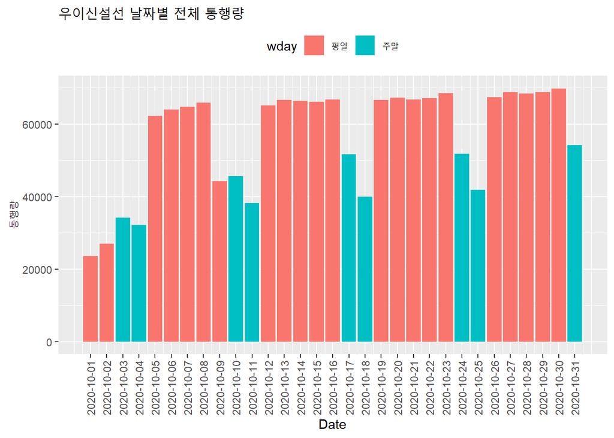

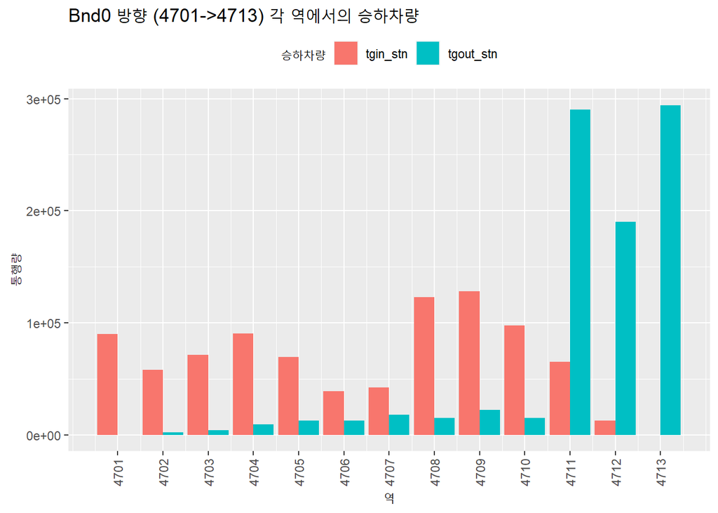

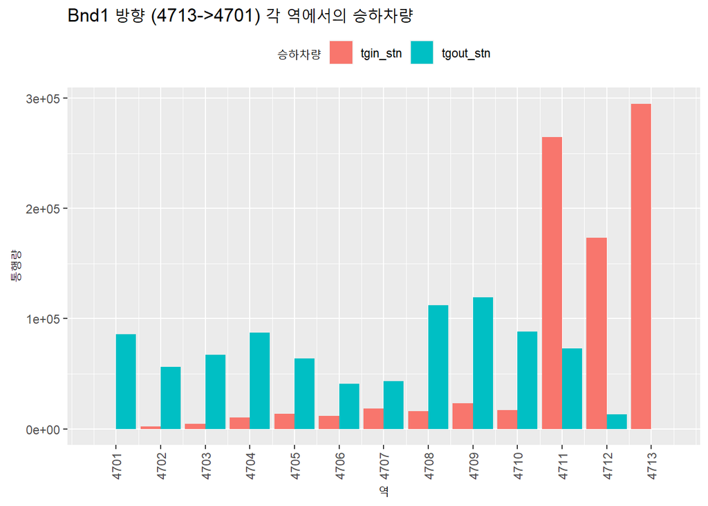

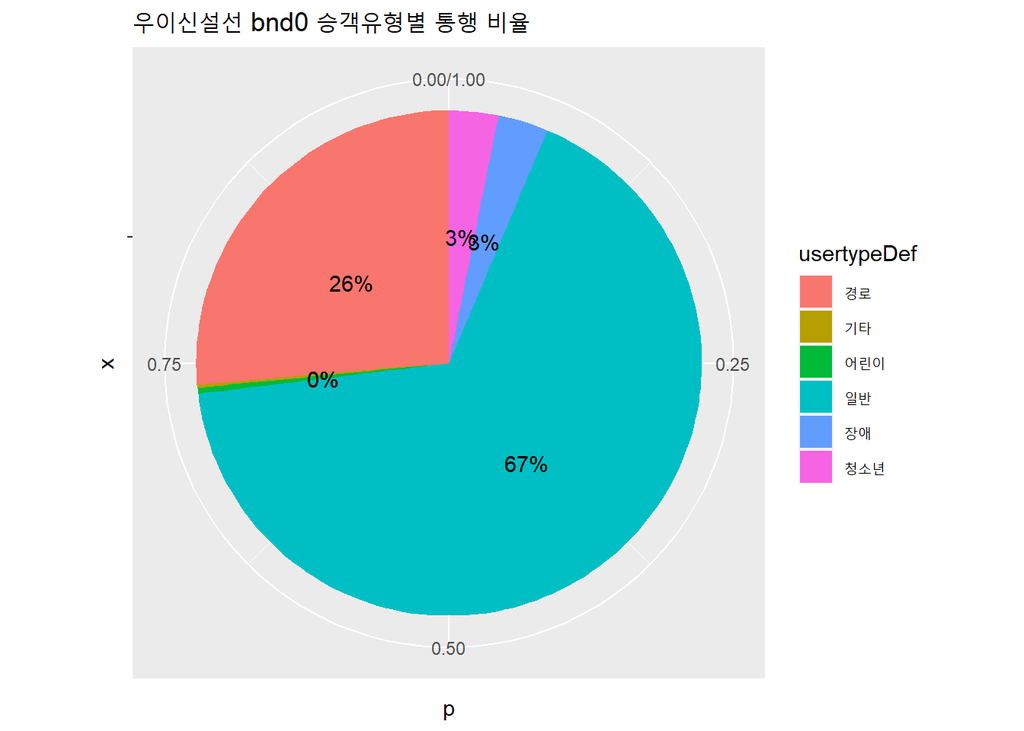

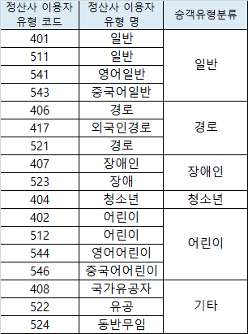

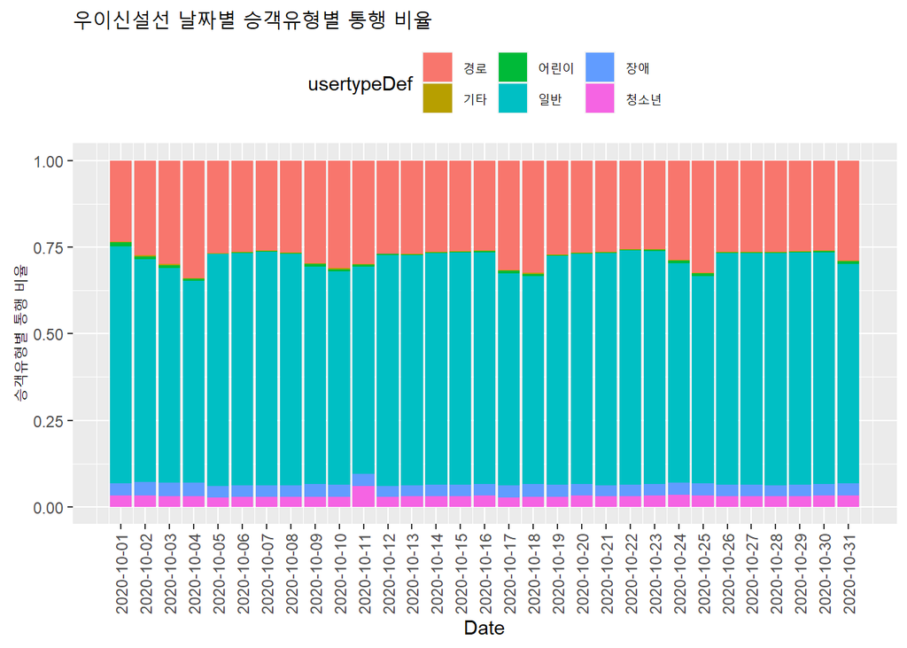

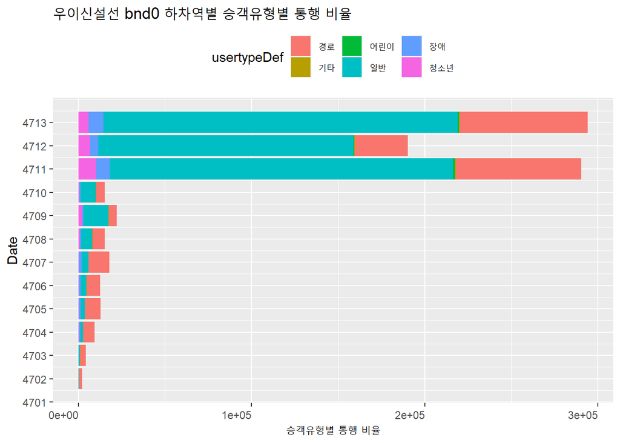

# 3. 데이터 처리

## 3.1. Reference Passenger 추출

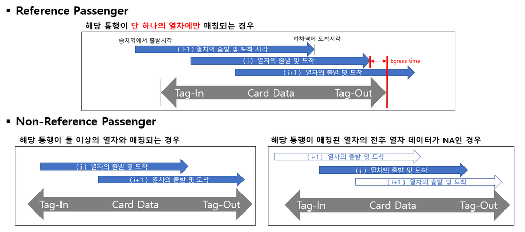

Reference Passenger

## 3.2. Reference Passenger 추출 결과

886237개 에서 689387개로 감소 (77.7881086%)

```
##   usertypeDef      n
## 1        경로 233655
## 2        기타   1645
## 3      어린이   3399
## 4        일반 591191
## 5        장애  28606
## 6      청소년  27741
```

```
##   usertypeDef      n
## 1        경로 176550
## 2        기타   1267
## 3      어린이   2603
## 4        일반 465715
## 5        장애  21832
## 6      청소년  21420
```

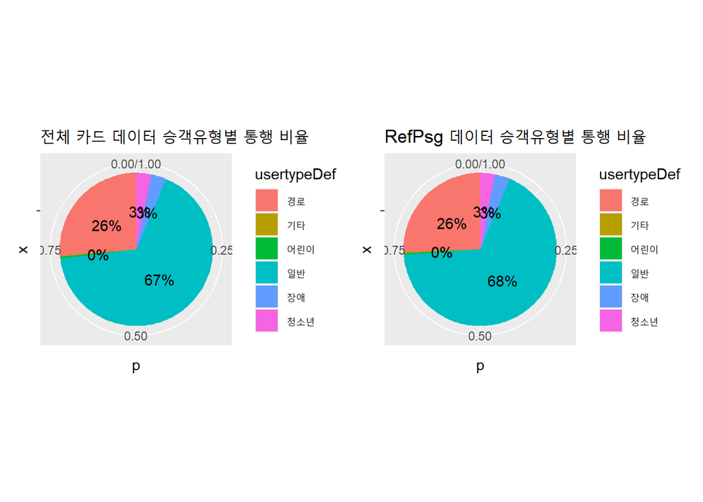

# 4. 결과

## 4.1. 승객 유형별 egress time 평균

일반 승객의 Egress Time 평균이 가장 낮게 나타나지만, 큰 차이를 보이지는 않음

```
## # A tibble: 6 x 3
##   usertypeDef egress_mean egress_ratio
##   <chr>             <dbl>        <dbl>
## 1 경로               84.8         1.06
## 2 기타               85.2         1.06
## 3 어린이             87.0         1.08
## 4 일반               80.2         1
## 5 장애               83.6         1.04
## 6 청소년             83.0         1.03
```

## 4.2. 역별 승객 유형별 egress time 평균 비교

```
##    tgout_stn 일반 평균 경로/일반 장애/일반 청소년/일반 어린이/일반
## 1       4702  40.09630 1.1539674 1.5262707   1.1896361   0.7856087
## 2       4703  39.61303 0.8994508 0.7220608   0.9517071   0.7383935
## 3       4704  36.13089 1.2601367 1.4830073   1.4932101   0.9453646
## 4       4705  37.82834 1.0685300 0.9598824   0.6859408   0.7117680
## 5       4706  59.70516 1.1606542 1.1065749   0.9313443   1.0205322
## 6       4707  57.54957 1.1805474 1.1937958   0.9163751   1.1433621
## 7       4708  54.80163 1.1642262 1.1305939   0.9240183   0.9964612
## 8       4709  51.34243 1.2074436 1.1567200   0.9808490   1.0956806
## 9       4710  54.68580 1.1362295 1.0978193   0.9023161   1.0936213
## 10      4711  59.35875 1.2681580 1.2715656   1.3956018   1.4659450
## 11      4712 106.21889 1.0867843 1.0513751   1.0171464   1.0883266
## 12      4713  88.82757 1.2013112 1.1328924   0.9754768   1.1438609
```

## 4.3. 승객유형별 상위 50% egress time의 평균 비교

```
##    tgout_stn 일반 평균 경로/일반 장애/일반 청소년/일반 어린이/일반
## 1       4702  61.04412 1.2153366 1.6182167   1.2253433   0.6989480
## 2       4703  56.21839 0.9057244 0.6597485   0.9249642   0.6285013
## 3       4704  55.14948 1.3297917 1.5835055   1.6004570   0.9208485
## 4       4705  55.79524 1.0923676 0.9529852   0.6181172   0.6183323
## 5       4706  71.91763 1.1580382 1.1170384   0.9433685   1.0284755
## 6       4707  70.29745 1.1828449 1.2227023   0.8790064   1.0962940
## 7       4708  65.03530 1.1626602 1.1606483   0.9081070   1.0155431
## 8       4709  61.26177 1.2341093 1.1937963   0.9587399   1.1159265
## 9       4710  64.56074 1.1333333 1.1161250   0.9023583   1.1376023
## 10      4711  82.78301 1.3317289 1.3557169   1.5168693   1.5611094
## 11      4712 125.24508 1.0681248 1.0393482   1.0162024   1.0839587
## 12      4713 105.13474 1.2415340 1.1678096   0.9735289   1.1668579
```

## 4.4. 성신여대입구역 실제 역 구조

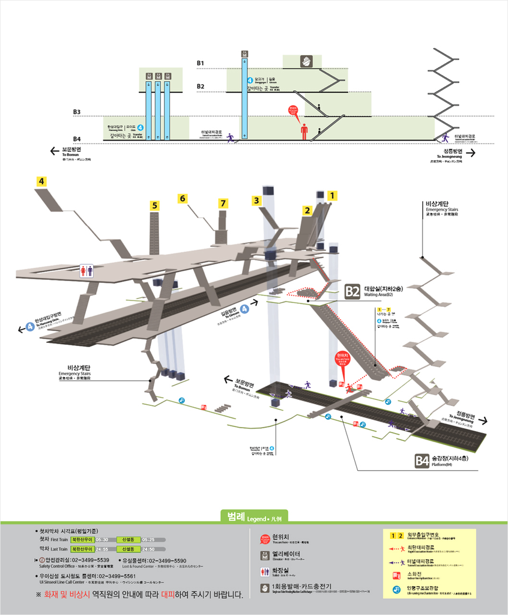

# 5. 결론

- 카드 데이터와 열차운행실적 데이터의 결합을 통해 승강장 내 이동시간을 알 수 있음
  - 데이터 상 일반 승객에 비해 교통약자의 통행 시간이 더 크게 나타남
  - 역 구조가 단순하고 작은 우이신설선에서는 승객 유형별 차이가 크지 않음
  - 9호선과 같이 좀 더 큰 호선에 적용함으로써 역별 차이를 비교해볼 수 있음
- 각 역에서 승객 유형별 이동시간에 영향을 미치는 요인 분석 필요